# Cyclistic_bike

Odwel

2023-02-28

Cyclistic Case Study

Defining the Problem

The main problem for the director of marketing and the marketing analytics team is: Design marketing strategies aimed at converting Cyclistic’s casual riders into annual members. There are three questions that will guide the future marketing program.

1-How do annual members and causal riders use Cyclistic bikes differently?

2-Why would casual riders buy Cyclistic annual memberships?

3-How can Cyclistic use digital media to influence casual riders to become members?

I was assigned with the first question; how annual members and causal riders use Cyclistic bikes differently.

Business Task

Analyze historical bike trip data from the previous 12 month to identify trends in how annual members and causal riders use Cyclistic bikes differently.

Data sources

We will be using the Cyclistic’s historical bike trip data from the last 12 months, which is publicly available here[link](https://divvy-tripdata.s3.amazonaws.com/index.html). The data is made available by Motivate international Inc. under this license [link](https://www.divvybikes.com/data-license-agreement). The data is stored in spreadsheets. There are 12.CSV files one for each month starting from February 2022 to January 2023.

The data is stored in structured form i.e., organized in rows and columns. Each record represents one trip, and each trip has a unique field that identifies it which is the ride_id column.

Now checking the data source for bias and credibility, The data source ROCCC:

• Reliable and Original: This public data contains accurate, complete, and unbiased info on Cyclistic’s historical bike trips from the previous 12 months

• Comprehensive and Current: These data source contain all the data needed to understand the ways members and casual riders use Cyclistic bikes. The data is from the previous 12 months which mean that it’s current and relevant to the business task.

Cited: The data source is publicly available and provided by the Cyclistic bike share in Chicago.

Data Cleaning and Manipulation

Initial data cleaning and manipulation using Microsoft Excel After downloading the 12-zip file and unzipping them, I house the files in my drive. Then I created a subfolder for the .CSV files and the .XLS file so that I have a copy of the original data.

I then launched Excel, open each file and did the following:

• I first checked for duplicate values, and the data contain no duplicate values.

• Then I checked if column “ended_at “is greater than column “started_at” by using the IF function to make the ended_at is always greater than started_at because it does not make sense for started_at to be greater than started_at.

• I then changed the format of the started_at and ended_at columns, Formatted as custom by Format > cells > custom > mm/dd/yyyy h:mm:ss

• Then I created a column called ride_length to calculate the length of each ride by subtracting the column “ended_at” from the column “started_at” and format as HH:MM:SS using format > cells > Time > HH:MM:SS (37:30:55).

• Created a column called ride_date by using =DATE(YEAR(C2),MONTH(C2),DAY(C2)) format > cells > date > MM/DD/YYYY.

• Created a column called day_of_week and calculate day of the week using the command WEEKDAY (example: =WEEKDAY(C2,1), format > cells > Number(no decimals) > 1,2,34. Note: 1 = Sunday and 7= Saturday.

• I then copy the values in this column and paste it using paste special > values After that I used find and replace to relace the day_of_week column from 1,2,3,4,5,6,7 to Sunday, Monday, Tuesday, Wednesday, Thursday, Friday, Saturday.

After this I made some descriptive analysis using two of the 12 files which are for February and March 2022 and discover the following:

• The average_ride_length for February and March are 0:14:14 and 0:18:30 respectively and the max_ride_length is 13:45:58 and 20:34:04 respectively and for February Monday was the day with the most rides with 22780 and for March it’s Wednesday with 50497 rides.

• Also, after creating some pivot table visual for both February and March I realize that casual riders tend to ride most on the weekends, especially on Sunday. Now for more in depth analyze, and since the data is big, I decided to continue my analyzes in RStudio.

## Setting my environment

Note: Setting my environment by loading the necessary R packages and importing the 12 data files

```r
library(tidyverse)
library(lubridate)
library(janitor)
```

## Imorting the 12 data files

```r
feb <- read.csv("feb_2022.csv")
mar <- read.csv("mar_2022.csv")
apr <- read.csv("apr_2022.csv")
may <- read.csv("may_2022.csv")
jun <- read.csv("jun_2022.csv")
jul <- read.csv("jul_2022.csv")
aug <- read.csv("aug_2022.csv")
sep <- read.csv("sep_2022.csv")
oct <- read.csv("oct_2022.csv")
nov <- read.csv("nov_2022.csv")
dec <- read.csv("dec_2022.csv")
jan <- read.csv("jan_2023.csv")
```

## Making sure the columns are consistent before merging them

```r
colnames(feb)
```

```
##  [1] "ride_id"            "rideable_type"      "started_at"
##  [4] "ended_at"           "start_station_name" "start_station_id"
##  [7] "end_station_name"   "end_station_id"     "start_lat"
## [10] "start_lng"          "end_lat"            "end_lng"
## [13] "member_casual"
```

```r
str(feb)
```

```
## 'data.frame':    115609 obs. of  13 variables:
##  $ ride_id           : chr  "E1E065E7ED285C02" "1602DCDC5B30FFE3" "BE7DD2AF4B55C4AF" "A1789BDF844412BE" ...
##  $ rideable_type     : chr  "classic_bike" "classic_bike" "classic_bike" "classic_bike" ...
##  $ started_at        : chr  "2022-02-19 18:08:41" "2022-02-20 17:41:30" "2022-02-25 18:55:56" "2022-02-14 11:57:03" ...
##  $ ended_at          : chr  "2022-02-19 18:23:56" "2022-02-20 17:45:56" "2022-02-25 19:09:34" "2022-02-14 12:04:00" ...
##  $ start_station_name: chr  "State St & Randolph St" "Halsted St & Wrightwood Ave" "State St & Randolph St" "Southport Ave & Waveland Ave" ...
##  $ start_station_id  : chr  "TA1305000029" "TA1309000061" "TA1305000029" "13235" ...
##  $ end_station_name  : chr  "Clark St & Lincoln Ave" "Southport Ave & Wrightwood Ave" "Canal St & Adams St" "Broadway & Sheridan Rd" ...
##  $ end_station_id    : chr  "13179" "TA1307000113" "13011" "13323" ...
##  $ start_lat         : num  41.9 41.9 41.9 41.9 41.9 ...
##  $ start_lng         : num  -87.6 -87.6 -87.6 -87.7 -87.6 ...
##  $ end_lat           : num  41.9 41.9 41.9 42 41.9 ...
##  $ end_lng           : num  -87.6 -87.7 -87.6 -87.6 -87.6 ...
##  $ member_casual     : chr  "member" "member" "member" "member" ...
```

```r
colnames(mar)
```

```
##  [1] "ride_id"            "rideable_type"      "started_at"
##  [4] "ended_at"           "start_station_name" "start_station_id"
##  [7] "end_station_name"   "end_station_id"     "start_lat"
## [10] "start_lng"          "end_lat"            "end_lng"
## [13] "member_casual"
```

```r
str(mar)
```

```
## 'data.frame':    284042 obs. of  13 variables:
##  $ ride_id           : chr  "47EC0A7F82E65D52" "8494861979B0F477" "EFE527AF80B66109" "9F446FD9DEE3F389" ...
##  $ rideable_type     : chr  "classic_bike" "electric_bike" "classic_bike" "classic_bike" ...
##  $ started_at        : chr  "2022-03-21 13:45:01" "2022-03-16 09:37:16" "2022-03-23 19:52:02" "2022-03-01 19:12:26" ...
##  $ ended_at          : chr  "2022-03-21 13:51:18" "2022-03-16 09:43:34" "2022-03-23 19:54:48" "2022-03-01 19:22:14" ...
##  $ start_station_name: chr  "Wabash Ave & Wacker Pl" "Michigan Ave & Oak St" "Broadway & Berwyn Ave" "Wabash Ave & Wacker Pl" ...
##  $ start_station_id  : chr  "TA1307000131" "13042" "13109" "TA1307000131" ...
##  $ end_station_name  : chr  "Kingsbury St & Kinzie St" "Orleans St & Chestnut St (NEXT Apts)" "Broadway & Ridge Ave" "Franklin St & Jackson Blvd" ...
##  $ end_station_id    : chr  "KA1503000043" "620" "15578" "TA1305000025" ...
##  $ start_lat         : num  41.9 41.9 42 41.9 41.9 ...
##  $ start_lng         : num  -87.6 -87.6 -87.7 -87.6 -87.6 ...
##  $ end_lat           : num  41.9 41.9 42 41.9 41.9 ...
##  $ end_lng           : num  -87.6 -87.6 -87.7 -87.6 -87.7 ...
##  $ member_casual     : chr  "member" "member" "member" "member" ...
```

```r
colnames(apr)
```

```
##  [1] "ride_id"            "rideable_type"      "started_at"
##  [4] "ended_at"           "start_station_name" "start_station_id"
##  [7] "end_station_name"   "end_station_id"     "start_lat"
## [10] "start_lng"          "end_lat"            "end_lng"
## [13] "member_casual"
```

```r
str(apr)
```

```
## 'data.frame':    371249 obs. of  13 variables:
##  $ ride_id           : chr  "3564070EEFD12711" "0B820C7FCF22F489" "89EEEE32293F07FF" "84D4751AEB31888D" ...
##  $ rideable_type     : chr  "electric_bike" "classic_bike" "classic_bike" "classic_bike" ...
##  $ started_at        : chr  "2022-04-06 17:42:48" "2022-04-24 19:23:07" "2022-04-20 19:29:08" "2022-04-22 21:14:06" ...
##  $ ended_at          : chr  "2022-04-06 17:54:36" "2022-04-24 19:43:17" "2022-04-20 19:35:16" "2022-04-22 21:23:29" ...
##  $ start_station_name: chr  "Paulina St & Howard St" "Wentworth Ave & Cermak Rd" "Halsted St & Polk St" "Wentworth Ave & Cermak Rd" ...
##  $ start_station_id  : chr  "515" "13075" "TA1307000121" "13075" ...
##  $ end_station_name  : chr  "University Library (NU)" "Green St & Madison St" "Green St & Madison St" "Delano Ct & Roosevelt Rd" ...
##  $ end_station_id    : chr  "605" "TA1307000120" "TA1307000120" "KA1706005007" ...
##  $ start_lat         : num  42 41.9 41.9 41.9 41.9 ...
##  $ start_lng         : num  -87.7 -87.6 -87.6 -87.6 -87.6 ...
##  $ end_lat           : num  42.1 41.9 41.9 41.9 41.9 ...
##  $ end_lng           : num  -87.7 -87.6 -87.6 -87.6 -87.6 ...
##  $ member_casual     : chr  "member" "member" "member" "casual" ...
```

```r
colnames(may)
```

```
##  [1] "ride_id"            "rideable_type"      "started_at"
##  [4] "ended_at"           "start_station_name" "start_station_id"
##  [7] "end_station_name"   "end_station_id"     "start_lat"
## [10] "start_lng"          "end_lat"            "end_lng"
## [13] "member_casual"
```

```r
str(may)
```

```
## 'data.frame':    634858 obs. of  13 variables:
##  $ ride_id           : chr  "EC2DE40644C6B0F4" "1C31AD03897EE385" "1542FBEC830415CF" "6FF59852924528F8" ...
##  $ rideable_type     : chr  "classic_bike" "classic_bike" "classic_bike" "classic_bike" ...
##  $ started_at        : chr  "2022-05-23 23:06:58" "2022-05-11 08:53:28" "2022-05-26 18:36:28" "2022-05-10 07:30:07" ...
##  $ ended_at          : chr  "2022-05-23 23:40:19" "2022-05-11 09:31:22" "2022-05-26 18:58:18" "2022-05-10 07:38:49" ...
##  $ start_station_name: chr  "Wabash Ave & Grand Ave" "DuSable Lake Shore Dr & Monroe St" "Clinton St & Madison St" "Clinton St & Madison St" ...
##  $ start_station_id  : chr  "TA1307000117" "13300" "TA1305000032" "TA1305000032" ...
##  $ end_station_name  : chr  "Halsted St & Roscoe St" "Field Blvd & South Water St" "Wood St & Milwaukee Ave" "Clark St & Randolph St" ...
##  $ end_station_id    : chr  "TA1309000025" "15534" "13221" "TA1305000030" ...
##  $ start_lat         : num  41.9 41.9 41.9 41.9 41.9 ...
##  $ start_lng         : num  -87.6 -87.6 -87.6 -87.6 -87.6 ...
##  $ end_lat           : num  41.9 41.9 41.9 41.9 41.9 ...
##  $ end_lng           : num  -87.6 -87.6 -87.7 -87.6 -87.7 ...
##  $ member_casual     : chr  "member" "member" "member" "member" ...
```

```r
colnames(jun)
```

```
##  [1] "ride_id"            "rideable_type"      "started_at"
##  [4] "ended_at"           "start_station_name" "start_station_id"
##  [7] "end_station_name"   "end_station_id"     "start_lat"
## [10] "start_lng"          "end_lat"            "end_lng"
## [13] "member_casual"
```

```r
str(jun)
```

```
## 'data.frame':    769204 obs. of  13 variables:
##  $ ride_id           : chr  "600CFD130D0FD2A4" "F5E6B5C1682C6464" "B6EB6D27BAD771D2" "C9C320375DE1D5C6" ...
##  $ rideable_type     : chr  "electric_bike" "electric_bike" "electric_bike" "electric_bike" ...
##  $ started_at        : chr  "2022-06-30 17:27:53" "2022-06-30 18:39:52" "2022-06-30 11:49:25" "2022-06-30 11:15:25" ...
##  $ ended_at          : chr  "2022-06-30 17:35:15" "2022-06-30 18:47:28" "2022-06-30 12:02:54" "2022-06-30 11:19:43" ...
##  $ start_station_name: chr  "" "" "" "" ...
##  $ start_station_id  : chr  "" "" "" "" ...
##  $ end_station_name  : chr  "" "" "" "" ...
##  $ end_station_id    : chr  "" "" "" "" ...
##  $ start_lat         : num  41.9 41.9 41.9 41.8 41.9 ...
##  $ start_lng         : num  -87.6 -87.6 -87.7 -87.7 -87.6 ...
##  $ end_lat           : num  41.9 41.9 41.9 41.8 41.9 ...
##  $ end_lng           : num  -87.6 -87.6 -87.6 -87.7 -87.6 ...
##  $ member_casual     : chr  "casual" "casual" "casual" "casual" ...
```

```r
colnames(jul)
```

```
##  [1] "ride_id"            "rideable_type"      "started_at"
##  [4] "ended_at"           "start_station_name" "start_station_id"
##  [7] "end_station_name"   "end_station_id"     "start_lat"
## [10] "start_lng"          "end_lat"            "end_lng"
## [13] "member_casual"
```

```r
str(jul)
```

```
## 'data.frame':    823488 obs. of  13 variables:
##  $ ride_id           : chr  "954144C2F67B1932" "292E027607D218B6" "57765852588AD6E0" "B5B6BE44314590E6" ...
##  $ rideable_type     : chr  "classic_bike" "classic_bike" "classic_bike" "classic_bike" ...
##  $ started_at        : chr  "2022-07-05 08:12:47" "2022-07-26 12:53:38" "2022-07-03 13:58:49" "2022-07-31 17:44:21" ...
##  $ ended_at          : chr  "2022-07-05 08:24:32" "2022-07-26 12:55:31" "2022-07-03 14:06:32" "2022-07-31 18:42:50" ...
##  $ start_station_name: chr  "Ashland Ave & Blackhawk St" "Buckingham Fountain (Temp)" "Buckingham Fountain (Temp)" "Buckingham Fountain (Temp)" ...
##  $ start_station_id  : chr  "13224" "15541" "15541" "15541" ...
##  $ end_station_name  : chr  "Kingsbury St & Kinzie St" "Michigan Ave & 8th St" "Michigan Ave & 8th St" "Woodlawn Ave & 55th St" ...
##  $ end_station_id    : chr  "KA1503000043" "623" "623" "TA1307000164" ...
##  $ start_lat         : num  41.9 41.9 41.9 41.9 41.9 ...
##  $ start_lng         : num  -87.7 -87.6 -87.6 -87.6 -87.6 ...
##  $ end_lat           : num  41.9 41.9 41.9 41.8 41.9 ...
##  $ end_lng           : num  -87.6 -87.6 -87.6 -87.6 -87.7 ...
##  $ member_casual     : chr  "member" "casual" "casual" "casual" ...
```

```r
colnames(aug)
```

```
##  [1] "ride_id"            "rideable_type"      "started_at"
##  [4] "ended_at"           "start_station_name" "start_station_id"
##  [7] "end_station_name"   "end_station_id"     "start_lat"
## [10] "start_lng"          "end_lat"            "end_lng"
## [13] "member_casual"
```

```r
str(aug)
```

```
## 'data.frame':    785932 obs. of  13 variables:
##  $ ride_id           : chr  "550CF7EFEAE0C618" "DAD198F405F9C5F5" "E6F2BC47B65CB7FD" "F597830181C2E13C" ...
##  $ rideable_type     : chr  "electric_bike" "electric_bike" "electric_bike" "electric_bike" ...
##  $ started_at        : chr  "2022-08-07 21:34:15" "2022-08-08 14:39:21" "2022-08-08 15:29:50" "2022-08-08 02:43:50" ...
##  $ ended_at          : chr  "2022-08-07 21:41:46" "2022-08-08 14:53:23" "2022-08-08 15:40:34" "2022-08-08 02:58:53" ...
##  $ start_station_name: chr  "" "" "" "" ...
##  $ start_station_id  : chr  "" "" "" "" ...
##  $ end_station_name  : chr  "" "" "" "" ...
##  $ end_station_id    : chr  "" "" "" "" ...
##  $ start_lat         : num  41.9 41.9 42 41.9 41.9 ...
##  $ start_lng         : num  -87.7 -87.6 -87.7 -87.7 -87.7 ...
##  $ end_lat           : num  41.9 41.9 42 42 41.8 ...
##  $ end_lng           : num  -87.7 -87.6 -87.7 -87.7 -87.7 ...
##  $ member_casual     : chr  "casual" "casual" "casual" "casual" ...
```

```r
colnames(sep)
```

```
##  [1] "ride_id"            "rideable_type"      "started_at"
##  [4] "ended_at"           "start_station_name" "start_station_id"
##  [7] "end_station_name"   "end_station_id"     "start_lat"
## [10] "start_lng"          "end_lat"            "end_lng"
## [13] "member_casual"
```

```r
str(sep)
```

```
## 'data.frame':    701339 obs. of  13 variables:
##  $ ride_id           : chr  "5156990AC19CA285" "E12D4A16BF51C274" "A02B53CD7DB72DD7" "C82E05FEE872DF11" ...
##  $ rideable_type     : chr  "electric_bike" "electric_bike" "electric_bike" "electric_bike" ...
##  $ started_at        : chr  "2022-09-01 08:36:22" "2022-09-01 17:11:29" "2022-09-01 17:15:50" "2022-09-01 09:00:28" ...
##  $ ended_at          : chr  "2022-09-01 08:39:05" "2022-09-01 17:14:45" "2022-09-01 17:16:12" "2022-09-01 09:10:32" ...
##  $ start_station_name: chr  "" "" "" "" ...
##  $ start_station_id  : chr  "" "" "" "" ...
##  $ end_station_name  : chr  "California Ave & Milwaukee Ave" "" "" "" ...
##  $ end_station_id    : chr  "13084" "" "" "" ...
##  $ start_lat         : num  41.9 41.9 41.9 41.9 41.9 ...
##  $ start_lng         : num  -87.7 -87.6 -87.6 -87.7 -87.7 ...
##  $ end_lat           : num  41.9 41.9 41.9 41.9 41.9 ...
##  $ end_lng           : num  -87.7 -87.6 -87.6 -87.7 -87.7 ...
##  $ member_casual     : chr  "casual" "casual" "casual" "casual" ...
```

```r
colnames(oct)
```

```
##  [1] "ride_id"            "rideable_type"      "started_at"
##  [4] "ended_at"           "start_station_name" "start_station_id"
##  [7] "end_station_name"   "end_station_id"     "start_lat"
## [10] "start_lng"          "end_lat"            "end_lng"
## [13] "member_casual"
```

```r
str(oct)
```

```
## 'data.frame':    558685 obs. of  13 variables:
##  $ ride_id           : chr  "A50255C1E17942AB" "DB692A70BD2DD4E3" "3C02727AAF60F873" "47E653FDC2D99236" ...
##  $ rideable_type     : chr  "classic_bike" "electric_bike" "electric_bike" "electric_bike" ...
##  $ started_at        : chr  "2022-10-14 17:13:30" "2022-10-01 16:29:26" "2022-10-19 18:55:40" "2022-10-31 07:52:36" ...
##  $ ended_at          : chr  "2022-10-14 17:19:39" "2022-10-01 16:49:06" "2022-10-19 19:03:30" "2022-10-31 07:58:49" ...
##  $ start_station_name: chr  "Noble St & Milwaukee Ave" "Damen Ave & Charleston St" "Hoyne Ave & Balmoral Ave" "Rush St & Cedar St" ...
##  $ start_station_id  : chr  "13290" "13288" "655" "KA1504000133" ...
##  $ end_station_name  : chr  "Larrabee St & Division St" "Damen Ave & Cullerton St" "Western Ave & Leland Ave" "Orleans St & Chestnut St (NEXT Apts)" ...
##  $ end_station_id    : chr  "KA1504000079" "13089" "TA1307000140" "620" ...
##  $ start_lat         : num  41.9 41.9 42 41.9 41.9 ...
##  $ start_lng         : num  -87.7 -87.7 -87.7 -87.6 -87.6 ...
##  $ end_lat           : num  41.9 41.9 42 41.9 41.9 ...
##  $ end_lng           : num  -87.6 -87.7 -87.7 -87.6 -87.6 ...
##  $ member_casual     : chr  "member" "casual" "member" "member" ...
```

```r
colnames(nov)
```

```
##  [1] "ride_id"            "rideable_type"      "started_at"
##  [4] "ended_at"           "start_station_name" "start_station_id"
##  [7] "end_station_name"   "end_station_id"     "start_lat"
## [10] "start_lng"          "end_lat"            "end_lng"
## [13] "member_casual"
```

```r
str(nov)
```

```
## 'data.frame':    337735 obs. of  13 variables:
##  $ ride_id           : chr  "BCC66FC6FAB27CC7" "772AB67E902C180F" "585EAD07FDEC0152" "91C4E7ED3C262FF9" ...
##  $ rideable_type     : chr  "electric_bike" "classic_bike" "classic_bike" "classic_bike" ...
##  $ started_at        : chr  "2022-11-10 06:21:55" "2022-11-04 07:31:55" "2022-11-21 17:20:29" "2022-11-25 17:29:34" ...
##  $ ended_at          : chr  "2022-11-10 06:31:27" "2022-11-04 07:46:25" "2022-11-21 17:34:36" "2022-11-25 17:45:15" ...
##  $ start_station_name: chr  "Canal St & Adams St" "Canal St & Adams St" "Indiana Ave & Roosevelt Rd" "Indiana Ave & Roosevelt Rd" ...
##  $ start_station_id  : chr  "13011" "13011" "SL-005" "SL-005" ...
##  $ end_station_name  : chr  "St. Clair St & Erie St" "St. Clair St & Erie St" "St. Clair St & Erie St" "St. Clair St & Erie St" ...
##  $ end_station_id    : chr  "13016" "13016" "13016" "13016" ...
##  $ start_lat         : num  41.9 41.9 41.9 41.9 41.9 ...
##  $ start_lng         : num  -87.6 -87.6 -87.6 -87.6 -87.6 ...
##  $ end_lat           : num  41.9 41.9 41.9 41.9 41.9 ...
##  $ end_lng           : num  -87.6 -87.6 -87.6 -87.6 -87.6 ...
##  $ member_casual     : chr  "member" "member" "member" "member" ...
```

```r
colnames(dec)
```

```
##  [1] "ride_id"            "rideable_type"      "started_at"
##  [4] "ended_at"           "start_station_name" "start_station_id"
##  [7] "end_station_name"   "end_station_id"     "start_lat"
## [10] "start_lng"          "end_lat"            "end_lng"
## [13] "member_casual"
```

```r
str(dec)
```

```
## 'data.frame':    181806 obs. of  13 variables:
##  $ ride_id           : chr  "65DBD2F447EC51C2" "0C201AA7EA0EA1AD" "E0B148CCB358A49D" "54C5775D2B7C9188" ...
##  $ rideable_type     : chr  "electric_bike" "classic_bike" "electric_bike" "classic_bike" ...
##  $ started_at        : chr  "2022-12-05 10:47:18" "2022-12-18 06:42:33" "2022-12-13 08:47:45" "2022-12-13 18:50:47" ...
##  $ ended_at          : chr  "2022-12-05 10:56:34" "2022-12-18 07:08:44" "2022-12-13 08:59:51" "2022-12-13 19:19:48" ...
##  $ start_station_name: chr  "Clifton Ave & Armitage Ave" "Broadway & Belmont Ave" "Sangamon St & Lake St" "Shields Ave & 31st St" ...
##  $ start_station_id  : chr  "TA1307000163" "13277" "TA1306000015" "KA1503000038" ...
##  $ end_station_name  : chr  "Sedgwick St & Webster Ave" "Sedgwick St & Webster Ave" "St. Clair St & Erie St" "Damen Ave & Madison St" ...
##  $ end_station_id    : chr  "13191" "13191" "13016" "13134" ...
##  $ start_lat         : num  41.9 41.9 41.9 41.8 41.9 ...
##  $ start_lng         : num  -87.7 -87.6 -87.7 -87.6 -87.7 ...
##  $ end_lat           : num  41.9 41.9 41.9 41.9 41.9 ...
##  $ end_lng           : num  -87.6 -87.6 -87.6 -87.7 -87.7 ...
##  $ member_casual     : chr  "member" "casual" "member" "member" ...
```

```r
colnames(jan)
```

```
##  [1] "ride_id"            "rideable_type"      "started_at"
##  [4] "ended_at"           "start_station_name" "start_station_id"
##  [7] "end_station_name"   "end_station_id"     "start_lat"
## [10] "start_lng"          "end_lat"            "end_lng"
## [13] "member_casual"
```

```r
str(jan)
```

```
## 'data.frame':    190301 obs. of  13 variables:
##  $ ride_id           : chr  "F96D5A74A3E41399" "13CB7EB698CEDB88" "BD88A2E670661CE5" "C90792D034FED968" ...
##  $ rideable_type     : chr  "electric_bike" "classic_bike" "electric_bike" "classic_bike" ...
##  $ started_at        : chr  "2023-01-21 20:05:42" "2023-01-10 15:37:36" "2023-01-02 07:51:57" "2023-01-22 10:52:58" ...
##  $ ended_at          : chr  "2023-01-21 20:16:33" "2023-01-10 15:46:05" "2023-01-02 08:05:11" "2023-01-22 11:01:44" ...
##  $ start_station_name: chr  "Lincoln Ave & Fullerton Ave" "Kimbark Ave & 53rd St" "Western Ave & Lunt Ave" "Kimbark Ave & 53rd St" ...
##  $ start_station_id  : chr  "TA1309000058" "TA1309000037" "RP-005" "TA1309000037" ...
##  $ end_station_name  : chr  "Hampden Ct & Diversey Ave" "Greenwood Ave & 47th St" "Valli Produce - Evanston Plaza" "Greenwood Ave & 47th St" ...
##  $ end_station_id    : chr  "202480.0" "TA1308000002" "599" "TA1308000002" ...
##  $ start_lat         : num  41.9 41.8 42 41.8 41.8 ...
##  $ start_lng         : num  -87.6 -87.6 -87.7 -87.6 -87.6 ...
##  $ end_lat           : num  41.9 41.8 42 41.8 41.8 ...
##  $ end_lng           : num  -87.6 -87.6 -87.7 -87.6 -87.6 ...
##  $ member_casual     : chr  "member" "member" "casual" "member" ...
```

## After making sure that the columns are consistent we now merge them in one single dataframe called bike_share

```r
bike_share <- rbind(feb, mar, apr, may, jun, jul, aug, sep, oct, nov, dec, jan)
```

```r
colnames(bike_share)
```

```
##  [1] "ride_id"            "rideable_type"      "started_at"
##  [4] "ended_at"           "start_station_name" "start_station_id"
##  [7] "end_station_name"   "end_station_id"     "start_lat"
## [10] "start_lng"          "end_lat"            "end_lng"
## [13] "member_casual"
```

```r
str(bike_share)
```

```
## 'data.frame':    5754248 obs. of  13 variables:
##  $ ride_id           : chr  "E1E065E7ED285C02" "1602DCDC5B30FFE3" "BE7DD2AF4B55C4AF" "A1789BDF844412BE" ...
##  $ rideable_type     : chr  "classic_bike" "classic_bike" "classic_bike" "classic_bike" ...
##  $ started_at        : chr  "2022-02-19 18:08:41" "2022-02-20 17:41:30" "2022-02-25 18:55:56" "2022-02-14 11:57:03" ...
##  $ ended_at          : chr  "2022-02-19 18:23:56" "2022-02-20 17:45:56" "2022-02-25 19:09:34" "2022-02-14 12:04:00" ...
##  $ start_station_name: chr  "State St & Randolph St" "Halsted St & Wrightwood Ave" "State St & Randolph St" "Southport Ave & Waveland Ave" ...
##  $ start_station_id  : chr  "TA1305000029" "TA1309000061" "TA1305000029" "13235" ...
##  $ end_station_name  : chr  "Clark St & Lincoln Ave" "Southport Ave & Wrightwood Ave" "Canal St & Adams St" "Broadway & Sheridan Rd" ...
##  $ end_station_id    : chr  "13179" "TA1307000113" "13011" "13323" ...
##  $ start_lat         : num  41.9 41.9 41.9 41.9 41.9 ...
##  $ start_lng         : num  -87.6 -87.6 -87.6 -87.7 -87.6 ...
##  $ end_lat           : num  41.9 41.9 41.9 42 41.9 ...
##  $ end_lng           : num  -87.6 -87.7 -87.6 -87.6 -87.6 ...
##  $ member_casual     : chr  "member" "member" "member" "member" ...
```

```r
head(bike_share)
```

```
##            ride_id rideable_type          started_at            ended_at
## 1 E1E065E7ED285C02  classic_bike 2022-02-19 18:08:41 2022-02-19 18:23:56
## 2 1602DCDC5B30FFE3  classic_bike 2022-02-20 17:41:30 2022-02-20 17:45:56
## 3 BE7DD2AF4B55C4AF  classic_bike 2022-02-25 18:55:56 2022-02-25 19:09:34
## 4 A1789BDF844412BE  classic_bike 2022-02-14 11:57:03 2022-02-14 12:04:00
## 5 07DE78092C62F7B3  classic_bike 2022-02-16 05:36:06 2022-02-16 05:39:00
## 6 9A2F204F04AB7E24  classic_bike 2022-02-07 09:51:57 2022-02-07 10:07:53
##             start_station_name start_station_id               end_station_name
## 1       State St & Randolph St     TA1305000029         Clark St & Lincoln Ave
## 2  Halsted St & Wrightwood Ave     TA1309000061 Southport Ave & Wrightwood Ave
## 3       State St & Randolph St     TA1305000029            Canal St & Adams St
## 4 Southport Ave & Waveland Ave            13235         Broadway & Sheridan Rd
## 5       State St & Randolph St     TA1305000029          Franklin St & Lake St
## 6       St. Clair St & Erie St            13016        Franklin St & Monroe St
##   end_station_id start_lat start_lng  end_lat   end_lng member_casual
## 1          13179  41.88462 -87.62783 41.91569 -87.63460        member
## 2   TA1307000113  41.92914 -87.64908 41.92877 -87.66391        member
## 3          13011  41.88462 -87.62783 41.87926 -87.63990        member
## 4          13323  41.94815 -87.66394 41.95283 -87.64999        member
## 5   TA1307000111  41.88462 -87.62783 41.88584 -87.63550        member
## 6   TA1309000007  41.89435 -87.62280 41.88032 -87.63519        member
```

### Now cleaning and manipulating bike_share to start our analyze

```r
bike_share$date <- as.Date(bike_share$started_at)
bike_share$month <- format(as.Date(bike_share$date),"%m")
bike_share$day < format(as.Date(bike_share$date),"%d")
```

```
## logical(0)
```

```r
bike_share$year <- format(as.Date(bike_share$date),"%Y")
bike_share$day_of_week <-format(as.Date(bike_share$date),"%A")
```

```r
colnames(bike_share)
```

```
##  [1] "ride_id"            "rideable_type"      "started_at"
##  [4] "ended_at"           "start_station_name" "start_station_id"
##  [7] "end_station_name"   "end_station_id"     "start_lat"
## [10] "start_lng"          "end_lat"            "end_lng"
## [13] "member_casual"      "date"               "month"
## [16] "year"               "day_of_week"
```

```r
head(bike_share)
```

```
##            ride_id rideable_type          started_at            ended_at
## 1 E1E065E7ED285C02  classic_bike 2022-02-19 18:08:41 2022-02-19 18:23:56
## 2 1602DCDC5B30FFE3  classic_bike 2022-02-20 17:41:30 2022-02-20 17:45:56
## 3 BE7DD2AF4B55C4AF  classic_bike 2022-02-25 18:55:56 2022-02-25 19:09:34
## 4 A1789BDF844412BE  classic_bike 2022-02-14 11:57:03 2022-02-14 12:04:00
## 5 07DE78092C62F7B3  classic_bike 2022-02-16 05:36:06 2022-02-16 05:39:00
## 6 9A2F204F04AB7E24  classic_bike 2022-02-07 09:51:57 2022-02-07 10:07:53
##             start_station_name start_station_id               end_station_name
## 1       State St & Randolph St     TA1305000029         Clark St & Lincoln Ave
## 2  Halsted St & Wrightwood Ave     TA1309000061 Southport Ave & Wrightwood Ave
## 3       State St & Randolph St     TA1305000029            Canal St & Adams St
## 4 Southport Ave & Waveland Ave            13235         Broadway & Sheridan Rd
## 5       State St & Randolph St     TA1305000029          Franklin St & Lake St
## 6       St. Clair St & Erie St            13016        Franklin St & Monroe St
##   end_station_id start_lat start_lng  end_lat   end_lng member_casual
## 1          13179  41.88462 -87.62783 41.91569 -87.63460        member
## 2   TA1307000113  41.92914 -87.64908 41.92877 -87.66391        member
## 3          13011  41.88462 -87.62783 41.87926 -87.63990        member
## 4          13323  41.94815 -87.66394 41.95283 -87.64999        member
## 5   TA1307000111  41.88462 -87.62783 41.88584 -87.63550        member
## 6   TA1309000007  41.89435 -87.62280 41.88032 -87.63519        member
##         date month year day_of_week
## 1 2022-02-19    02 2022    Saturday
## 2 2022-02-20    02 2022      Sunday
## 3 2022-02-25    02 2022      Friday
## 4 2022-02-14    02 2022      Monday
## 5 2022-02-16    02 2022   Wednesday
## 6 2022-02-07    02 2022      Monday
```

```r
tail(bike_share)
```

```
##                  ride_id rideable_type          started_at            ended_at
## 5754243 A3DC3E8358DB1FAA electric_bike 2023-01-17 18:36:00 2023-01-17 19:00:26
## 5754244 A303816F2E8A35A8 electric_bike 2023-01-11 17:46:23 2023-01-11 17:57:31
## 5754245 BCDBB142CC610382  classic_bike 2023-01-30 15:08:10 2023-01-30 15:33:26
## 5754246 7D1C7CA80517183B  classic_bike 2023-01-06 19:34:50 2023-01-06 19:50:01
## 5754247 1A4EB636346DF527  classic_bike 2023-01-13 18:59:24 2023-01-13 19:14:44
## 5754248 069971675AC7DC62 electric_bike 2023-01-02 13:48:29 2023-01-02 13:59:29
##               start_station_name start_station_id             end_station_name
## 5754243        Clark St & Elm St     TA1307000039 Southport Ave & Clybourn Ave
## 5754244        Clark St & Elm St     TA1307000039 Southport Ave & Clybourn Ave
## 5754245 Western Ave & Leland Ave     TA1307000140   Clarendon Ave & Gordon Ter
## 5754246        Clark St & Elm St     TA1307000039 Southport Ave & Clybourn Ave
## 5754247        Clark St & Elm St     TA1307000039 Southport Ave & Clybourn Ave
## 5754248        Clark St & Elm St     TA1307000039 Southport Ave & Clybourn Ave
##         end_station_id start_lat start_lng  end_lat   end_lng member_casual
## 5754243   TA1309000030  41.90276 -87.63149 41.92077 -87.66371        casual
## 5754244   TA1309000030  41.90263 -87.63159 41.92077 -87.66371        casual
## 5754245          13379  41.96640 -87.68870 41.95787 -87.64951        member
## 5754246   TA1309000030  41.90297 -87.63128 41.92077 -87.66371        casual
## 5754247   TA1309000030  41.90297 -87.63128 41.92077 -87.66371        casual
## 5754248   TA1309000030  41.90282 -87.63169 41.92077 -87.66371        casual
##               date month year day_of_week
## 5754243 2023-01-17    01 2023     Tuesday
## 5754244 2023-01-11    01 2023   Wednesday
## 5754245 2023-01-30    01 2023      Monday
## 5754246 2023-01-06    01 2023      Friday
## 5754247 2023-01-13    01 2023      Friday
## 5754248 2023-01-02    01 2023      Monday
```

```r
bike_share$ride_length <- difftime(bike_share$ended_at, bike_share$started_at)
```

```r
colnames(bike_share)
```

```
##  [1] "ride_id"            "rideable_type"      "started_at"
##  [4] "ended_at"           "start_station_name" "start_station_id"
##  [7] "end_station_name"   "end_station_id"     "start_lat"
## [10] "start_lng"          "end_lat"            "end_lng"
## [13] "member_casual"      "date"               "month"
## [16] "year"               "day_of_week"        "ride_length"
```

```r
str(bike_share)
```

```
## 'data.frame':    5754248 obs. of  18 variables:
##  $ ride_id           : chr  "E1E065E7ED285C02" "1602DCDC5B30FFE3" "BE7DD2AF4B55C4AF" "A1789BDF844412BE" ...
##  $ rideable_type     : chr  "classic_bike" "classic_bike" "classic_bike" "classic_bike" ...
##  $ started_at        : chr  "2022-02-19 18:08:41" "2022-02-20 17:41:30" "2022-02-25 18:55:56" "2022-02-14 11:57:03" ...
##  $ ended_at          : chr  "2022-02-19 18:23:56" "2022-02-20 17:45:56" "2022-02-25 19:09:34" "2022-02-14 12:04:00" ...
##  $ start_station_name: chr  "State St & Randolph St" "Halsted St & Wrightwood Ave" "State St & Randolph St" "Southport Ave & Waveland Ave" ...
##  $ start_station_id  : chr  "TA1305000029" "TA1309000061" "TA1305000029" "13235" ...
##  $ end_station_name  : chr  "Clark St & Lincoln Ave" "Southport Ave & Wrightwood Ave" "Canal St & Adams St" "Broadway & Sheridan Rd" ...
##  $ end_station_id    : chr  "13179" "TA1307000113" "13011" "13323" ...
##  $ start_lat         : num  41.9 41.9 41.9 41.9 41.9 ...
##  $ start_lng         : num  -87.6 -87.6 -87.6 -87.7 -87.6 ...
##  $ end_lat           : num  41.9 41.9 41.9 42 41.9 ...
##  $ end_lng           : num  -87.6 -87.7 -87.6 -87.6 -87.6 ...
##  $ member_casual     : chr  "member" "member" "member" "member" ...
##  $ date              : Date, format: "2022-02-19" "2022-02-20" ...
##  $ month             : chr  "02" "02" "02" "02" ...
##  $ year              : chr  "2022" "2022" "2022" "2022" ...
##  $ day_of_week       : chr  "Saturday" "Sunday" "Friday" "Monday" ...
##  $ ride_length       : 'difftime' num  915 266 818 417 ...
##   ..- attr(*, "units")= chr "secs"
```

```r
glimpse(bike_share)
```

```
## Rows: 5,754,248
## Columns: 18
## $ ride_id            <chr> "E1E065E7ED285C02", "1602DCDC5B30FFE3", "BE7DD2AF4B…
## $ rideable_type      <chr> "classic_bike", "classic_bike", "classic_bike", "cl…
## $ started_at         <chr> "2022-02-19 18:08:41", "2022-02-20 17:41:30", "2022…
## $ ended_at           <chr> "2022-02-19 18:23:56", "2022-02-20 17:45:56", "2022…
## $ start_station_name <chr> "State St & Randolph St", "Halsted St & Wrightwood …
## $ start_station_id   <chr> "TA1305000029", "TA1309000061", "TA1305000029", "13…
## $ end_station_name   <chr> "Clark St & Lincoln Ave", "Southport Ave & Wrightwo…
## $ end_station_id     <chr> "13179", "TA1307000113", "13011", "13323", "TA13070…
## $ start_lat          <dbl> 41.88462, 41.92914, 41.88462, 41.94815, 41.88462, 4…
## $ start_lng          <dbl> -87.62783, -87.64908, -87.62783, -87.66394, -87.627…
## $ end_lat            <dbl> 41.91569, 41.92877, 41.87926, 41.95283, 41.88584, 4…
## $ end_lng            <dbl> -87.63460, -87.66391, -87.63990, -87.64999, -87.635…
## $ member_casual      <chr> "member", "member", "member", "member", "member", "…
## $ date               <date> 2022-02-19, 2022-02-20, 2022-02-25, 2022-02-14, 20…
## $ month              <chr> "02", "02", "02", "02", "02", "02", "02", "02", "02…
## $ year               <chr> "2022", "2022", "2022", "2022", "2022", "2022", "20…
## $ day_of_week        <chr> "Saturday", "Sunday", "Friday", "Monday", "Wednesda…
## $ ride_length        <drtn> 915 secs, 266 secs, 818 secs, 417 secs, 174 secs, …
```

### Changing the data type of the ride_length column to numeric

```r
bike_share$ride_length <- as.numeric(as.character(bike_share$ride_length))
is.numeric(bike_share$ride_length)
```

```
## [1] TRUE
```

```r
str(bike_share)
```

```
## 'data.frame':    5754248 obs. of  18 variables:
##  $ ride_id           : chr  "E1E065E7ED285C02" "1602DCDC5B30FFE3" "BE7DD2AF4B55C4AF" "A1789BDF844412BE" ...
##  $ rideable_type     : chr  "classic_bike" "classic_bike" "classic_bike" "classic_bike" ...
##  $ started_at        : chr  "2022-02-19 18:08:41" "2022-02-20 17:41:30" "2022-02-25 18:55:56" "2022-02-14 11:57:03" ...
##  $ ended_at          : chr  "2022-02-19 18:23:56" "2022-02-20 17:45:56" "2022-02-25 19:09:34" "2022-02-14 12:04:00" ...
##  $ start_station_name: chr  "State St & Randolph St" "Halsted St & Wrightwood Ave" "State St & Randolph St" "Southport Ave & Waveland Ave" ...
##  $ start_station_id  : chr  "TA1305000029" "TA1309000061" "TA1305000029" "13235" ...
##  $ end_station_name  : chr  "Clark St & Lincoln Ave" "Southport Ave & Wrightwood Ave" "Canal St & Adams St" "Broadway & Sheridan Rd" ...
##  $ end_station_id    : chr  "13179" "TA1307000113" "13011" "13323" ...
##  $ start_lat         : num  41.9 41.9 41.9 41.9 41.9 ...
##  $ start_lng         : num  -87.6 -87.6 -87.6 -87.7 -87.6 ...
##  $ end_lat           : num  41.9 41.9 41.9 42 41.9 ...
##  $ end_lng           : num  -87.6 -87.7 -87.6 -87.6 -87.6 ...
##  $ member_casual     : chr  "member" "member" "member" "member" ...
##  $ date              : Date, format: "2022-02-19" "2022-02-20" ...
##  $ month             : chr  "02" "02" "02" "02" ...
##  $ year              : chr  "2022" "2022" "2022" "2022" ...
##  $ day_of_week       : chr  "Saturday" "Sunday" "Friday" "Monday" ...
##  $ ride_length       : num  915 266 818 417 174 956 229 523 338 350 ...
```

## Remove “bad” data

```r
all_trips <- bike_share[!(bike_share$ride_length <=0),]
```

```r
head(all_trips)
```

```
##            ride_id rideable_type          started_at            ended_at
## 1 E1E065E7ED285C02  classic_bike 2022-02-19 18:08:41 2022-02-19 18:23:56
## 2 1602DCDC5B30FFE3  classic_bike 2022-02-20 17:41:30 2022-02-20 17:45:56
## 3 BE7DD2AF4B55C4AF  classic_bike 2022-02-25 18:55:56 2022-02-25 19:09:34
## 4 A1789BDF844412BE  classic_bike 2022-02-14 11:57:03 2022-02-14 12:04:00
## 5 07DE78092C62F7B3  classic_bike 2022-02-16 05:36:06 2022-02-16 05:39:00
## 6 9A2F204F04AB7E24  classic_bike 2022-02-07 09:51:57 2022-02-07 10:07:53
##             start_station_name start_station_id               end_station_name
## 1       State St & Randolph St     TA1305000029         Clark St & Lincoln Ave
## 2  Halsted St & Wrightwood Ave     TA1309000061 Southport Ave & Wrightwood Ave
## 3       State St & Randolph St     TA1305000029            Canal St & Adams St
## 4 Southport Ave & Waveland Ave            13235         Broadway & Sheridan Rd
## 5       State St & Randolph St     TA1305000029          Franklin St & Lake St
## 6       St. Clair St & Erie St            13016        Franklin St & Monroe St
##   end_station_id start_lat start_lng  end_lat   end_lng member_casual
## 1          13179  41.88462 -87.62783 41.91569 -87.63460        member
## 2   TA1307000113  41.92914 -87.64908 41.92877 -87.66391        member
## 3          13011  41.88462 -87.62783 41.87926 -87.63990        member
## 4          13323  41.94815 -87.66394 41.95283 -87.64999        member
## 5   TA1307000111  41.88462 -87.62783 41.88584 -87.63550        member
## 6   TA1309000007  41.89435 -87.62280 41.88032 -87.63519        member
##         date month year day_of_week ride_length
## 1 2022-02-19    02 2022    Saturday         915
## 2 2022-02-20    02 2022      Sunday         266
## 3 2022-02-25    02 2022      Friday         818
## 4 2022-02-14    02 2022      Monday         417
## 5 2022-02-16    02 2022   Wednesday         174
## 6 2022-02-07    02 2022      Monday         956
```

## Analyze the data by conducting descriptive analysis

Note: by performing statistical analysis by calculating mean, median, maximum and minimum of ride_length for both casual riders and members.

```r
all_trips %>% group_by(member_casual) %>%
  summarise(average_ride_length = mean(ride_length), median_length = median(ride_length), max_ride_length = max(ride_length), min_ride_length = min(ride_length))
```

```
## # A tibble: 2 × 5
##   member_casual average_ride_length median_length max_ride_length min_ride_len…¹
##   <chr>                       <dbl>         <dbl>           <dbl>          <dbl>
## 1 casual                      1742.           775         2483235              1
## 2 member                       758.           526           93594              1
## # … with abbreviated variable name ¹min_ride_length
```

#### Calculating the total number of rides

```r
all_trips %>% group_by(member_casual) %>%
  summarise(total_ride = n())
```

```
## # A tibble: 2 × 2
##   member_casual total_ride
##   <chr>              <int>
## 1 casual           2343257
## 2 member           3410457
```

### Calculating average ride length and number of rides per day of week for casual riders and members

```r
all_trips %>% group_by(member_casual, day_of_week) %>%
  summarise(number_of_rides = n(), average_ride_length = mean(ride_length),.groups = "drop")
```

```
## # A tibble: 14 × 4
##    member_casual day_of_week number_of_rides average_ride_length
##    <chr>         <chr>                 <int>               <dbl>
##  1 casual        Friday               337222               1677.
##  2 casual        Monday               280918               1743.
##  3 casual        Saturday             474356               1950.
##  4 casual        Sunday               392842               2046.
##  5 casual        Thursday             311775               1525.
##  6 casual        Tuesday              268216               1541.
##  7 casual        Wednesday            277928               1472.
##  8 member        Friday               475806                748.
##  9 member        Monday               482579                732.
## 10 member        Saturday             447047                844.
## 11 member        Sunday               394176                837.
## 12 member        Thursday             540848                732.
## 13 member        Tuesday              534207                721.
## 14 member        Wednesday            535794                721.
```

## Sharing our insight through visualization

#### Visualizing total number of rides taken by members and casual riders

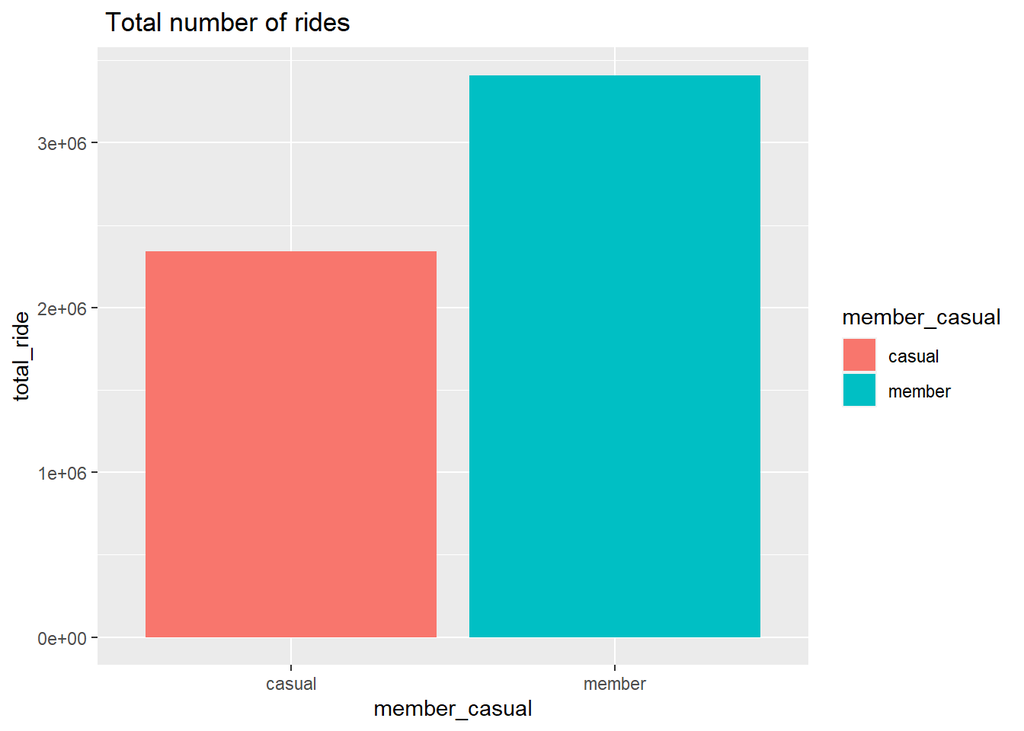

```r
all_trips %>% group_by(member_casual) %>%
  summarise(total_ride = n()) %>%
  ggplot() +
  geom_col(mapping = aes(x = member_casual, y = total_ride, fill = member_casual)) + labs(title = " Total number of rides")
```

### visualize the number of rides by rider type

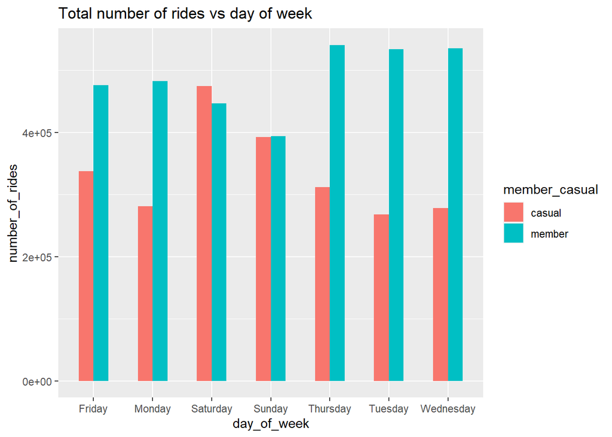

```r
all_trips %>% group_by(member_casual, day_of_week) %>%
  summarise(number_of_rides = n(),.groups = "drop") %>%
  arrange(member_casual, day_of_week) %>%
  ggplot(aes(x = day_of_week, y = number_of_rides, fill = member_casual))+  geom_col(width = 0.5, position = position_dodge(width = 0.5)) +
  labs(title = "Total number of rides vs day of week")
```

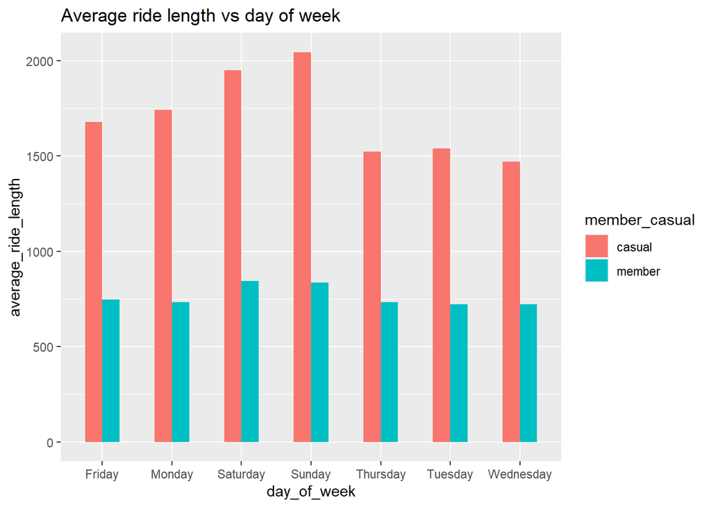

```r
all_trips %>% group_by(member_casual, day_of_week) %>%
  summarise(average_ride_length = mean(ride_length),.groups = "drop") %>%
  arrange(member_casual, day_of_week) %>%
  ggplot(aes(x = day_of_week, y = average_ride_length, fill = member_casual)) +
  geom_col(width = 0.5, position = position_dodge(width = 0.5)) +
  labs(title = "Average ride length vs day of week")
```

#### Visualizing total rides taken by riders per month.

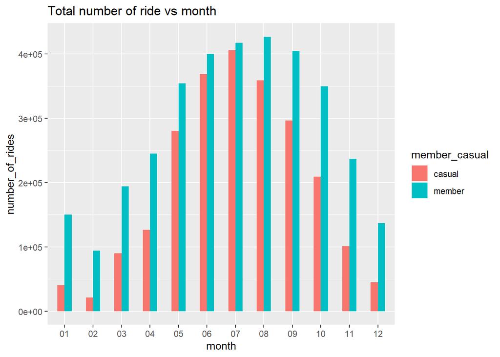

```r
all_trips %>% group_by(member_casual, month) %>%
  summarise(number_of_rides = n(),.groups = "drop") %>%
  arrange(member_casual, month) %>%
  ggplot(aes(x = month, y = number_of_rides, fill = member_casual)) +
  geom_col(width = 0.5, position = position_dodge(width = 0.5)) +
  labs(title = "Total number of ride vs month")
```

#### Visualizing average length of riders per month

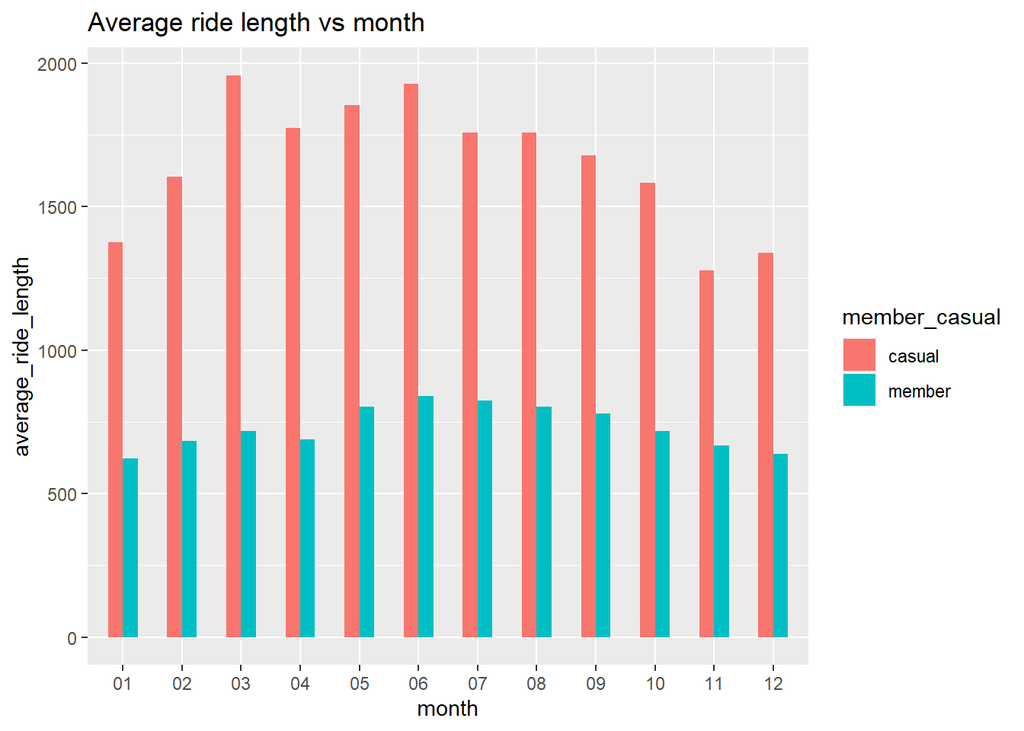

```r
all_trips %>% group_by(member_casual, month) %>%
  summarise(average_ride_length = mean(ride_length),.groups = "drop") %>%
  arrange(member_casual, month) %>%
  ggplot(aes(x = month, y = average_ride_length, fill = member_casual)) +
  geom_col(width = 0.5, position = position_dodge(width = 0.5)) +
  labs(title = "Average ride length vs month")
```

#### Visualizing of total number of rides and their ride type

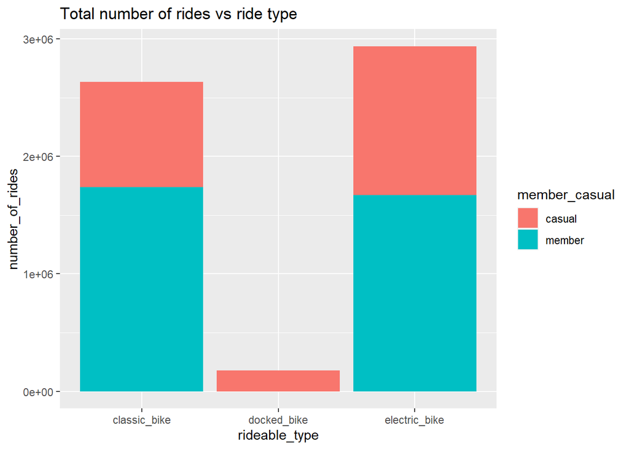

```r
all_trips %>% group_by(member_casual, rideable_type) %>%
  summarise(number_of_rides = n(),.groups = "drop") %>%
  arrange(member_casual, rideable_type) %>%
  ggplot() +geom_col(mapping = aes(x = rideable_type, y = number_of_rides, fill = member_casual)) +
  labs(title = "Total number of rides vs ride type")
```